# Analyses of seasonal and latitudinal distribution of larval fish in temperate waters of south-eastern Australia

Charles Hinchliffe

# Summary

This script contains code to reproduce the analyses and figures from Hinchliffe C et al 2020, “Seasonal and latitudinal distribution of larval fish in temperate waters of south-eastern Australia” (Link).

There are 3 major analyses within the manuscript. The first two involve analysis of the seasonal and latitudinal variation in larval fish abundance and taxa richness using generalised additive mixed-models (GAMMs) and can be found in section 2) and 3) in this script. The third major analyses involves investigation of the community composition of larval fish across the study area, first in relation to Sea Surface Temperature (SST), followed by Latitude (which appears in the supplementary material of the manuscript), and can be found in section 4) of this script. The figures associated with each analysis are at the end of each section, with there figure number as they appear in the manuscript and figure caption.

# 1) Data manipulation and cleaning

This section of the script cleans data and creates variables required for the subsequent analyses.

load required packages for all analyses and figure building.

```r
library(tidyverse)
library(mgcv)
library(vegan)
library(car)
library(lubridate)
library(pracma)
#install_github('gavinsimpson/gratia')
library(gratia)
library(lctools)
library(ggplot2)
library(gridGraphics)
library(cowplot)
library(ggpubr)
library("grid")
library("ggplotify")
library(mvabund)
#install ecoCopula
#devtools::install_github("gordy2x/ecoCopula",force=TRUE)
library(ecoCopula)
library(quantreg)
```

bring in data

```r
nimo.data <- read.csv("all_data.csv", header=TRUE)
#head(nimo.data)
```

Make bathymetry absolute values in km units

```r
nimo.data$Bathy <- (abs(nimo.data$Bathy)/1000)
#summary(nimo.data$Bathy)
```

Create date variables

```r
nimo.data$DateCaught <- as.Date(nimo.data$Date, "%d/%m/%Y")
nimo.data$Month <- month(nimo.data$Date)
#summary(nimo.data$Month)
nimo.data$Year <- year(nimo.data$DateCaught)
nimo.data$Day <- day(nimo.data$DateCaught)
#summary(nimo.data$Day)

nimo.data$dayofyear <- yday(nimo.data$DateCaught)
#summary(nimo.data$dayofyear)
#hist(nimo.data$dayofyear)
```

Create season variables

```r
nimo.data$Month <- as.factor(nimo.data$Month) #month as factor

nimo.data$Season <- "0" #make season variable

nimo.data$Season[nimo.data$Month  == "12"] <- "summer"
nimo.data$Season[nimo.data$Month  == "1"] <- "summer"
nimo.data$Season[nimo.data$Month  == "2"] <- "summer"

nimo.data$Season[nimo.data$Month  == "3"] <- "autumn"
nimo.data$Season[nimo.data$Month  == "4"] <- "autumn"
nimo.data$Season[nimo.data$Month  == "5"] <- "autumn"

nimo.data$Season[nimo.data$Month  == "6"] <- "winter"
nimo.data$Season[nimo.data$Month  == "7"] <- "winter"
nimo.data$Season[nimo.data$Month  == "8"] <- "winter"

nimo.data$Season[nimo.data$Month  == "9"] <- "spring"
nimo.data$Season[nimo.data$Month  == "10"] <- "spring"
nimo.data$Season[nimo.data$Month  == "11"] <- "spring"

nimo.data$Season <- as.factor(nimo.data$Season)
nimo.data$Month <- as.numeric(nimo.data$Month)
```

Create time period variables

```r
nimo.data$Decade[nimo.data$Year  <= 1999] <- "1990s"
nimo.data$Decade[nimo.data$Year  <= 2009 & nimo.data$Year > 1999] <- "2000s"
nimo.data$Decade[nimo.data$Year  <= 2020 & nimo.data$Year > 2009] <- "2010s"

nimo.data$Period[nimo.data$Year  <= 1998] <- "pre1998"
nimo.data$Period[nimo.data$Year  >= 1999] <- "post1998"

nimo.data$Decade <- as.factor(nimo.data$Decade)
#summary(nimo.data$Decade)

nimo.data$Period <- as.factor(nimo.data$Period)
#summary(nimo.data$Period)
```

Create latitudinal region variable

```r
nimo.data$Region[nimo.data$Latitude  <= -40] <- "South"

nimo.data$Region[nimo.data$Latitude  <= -35 & nimo.data$Latitude > -40] <- "Mid-South"

nimo.data$Region[nimo.data$Latitude  <= -30 & nimo.data$Latitude > -35] <- "Mid-North"

nimo.data$Region[nimo.data$Latitude  > -30] <- "North"

nimo.data$Region <- as.factor(nimo.data$Region)

nimo.data$Region <- as.factor(nimo.data$Region)
nimo.data$Region <- factor(nimo.data$Region, ordered = TRUE, levels = c("North", "Mid-North", "Mid-South","South"))
#summary(nimo.data$Region)
```

Create mid-point standardised sampling depth variable

```r
nimo.data$stand_depth <- as.character(nimo.data$Gear_depth_m)



nimo.data$stand_depth[nimo.data$stand_depth  == "0-25"] <- "25" #double mid point

nimo.data$stand_depth[nimo.data$stand_depth  == "0-30"] <- "30"

nimo.data$stand_depth[nimo.data$stand_depth  == "0-35"] <- "35"

nimo.data$stand_depth[nimo.data$stand_depth  == "0-40"] <- "40"

nimo.data$stand_depth[nimo.data$stand_depth  == "0-50"] <- "50"

nimo.data$stand_depth[nimo.data$stand_depth  == "0-80"] <- "80"

nimo.data$stand_depth[nimo.data$stand_depth  == "25-50"] <- "75"

nimo.data$stand_depth[nimo.data$stand_depth  == "50-75"] <- "125"

nimo.data$stand_depth[nimo.data$stand_depth  == "75-100"] <- "175"



nimo.data$stand_depth <- as.factor(nimo.data$stand_depth)

nimo.data$stand_depth <- as.numeric(nimo.data$stand_depth)

nimo.data$stand_depth <- (nimo.data$stand_depth/2)
```

Create sampling depth factors

```r
nimo.data$depth_sect[nimo.data$stand_depth  >= 0 & nimo.data$stand_depth < 11] <- "a) 0-10"

nimo.data$depth_sect[nimo.data$stand_depth  >= 11 & nimo.data$stand_depth < 50] <- "b) 11-50"

nimo.data$depth_sect[nimo.data$stand_depth  >= 51 & nimo.data$stand_depth < 100] <- "c) 51-100"

nimo.data$depth_sect[nimo.data$stand_depth  >= 101 & nimo.data$stand_depth < 150] <- "d) 101-150"

nimo.data$depth_sect[nimo.data$stand_depth  >= 151] <- "e) 151+"

nimo.data$depth_sect <- as.factor(nimo.data$depth_sect)
```

Creating diversity variables

```r
larval.spp<-nimo.data[1:3193,22:241]

abundance <- rowSums(larval.spp)
richness <- specnumber(larval.spp) # richness
shannon <- diversity(larval.spp) #shannon weaver index from vegan package
J <- shannon/log(specnumber(larval.spp)) # Evenness
shannon_effective <- exp(diversity(larval.spp))


nimo.data$shannon <- shannon
nimo.data$evenness <- J
nimo.data$richness <- richness
nimo.data$abundance <- abundance
nimo.data$shannon_effective <- shannon_effective
```

## Separate Australian west coast and east coast

Samples into separate data frames

```r
eastcoast <- subset(nimo.data, nimo.data$Longitude >= 130)
westcoast <- subset(nimo.data, nimo.data$Longitude <= 130)
```

Check SST and Hadley Centre Global Sea Ice and Sea Surface Temperature (HadISST) correlation on east coast

```r
eastcoast$SST <- as.numeric(eastcoast$SST)
eastcoast$HadISST <- as.numeric(eastcoast$HadISST)

cor.test(eastcoast$SST,eastcoast$HadISST, method = c("pearson", "kendall", "spearman"))
```

```
##
##  Pearson's product-moment correlation
##
## data:  eastcoast$SST and eastcoast$HadISST
## t = 108.89, df = 1443, p-value < 2.2e-16
## alternative hypothesis: true correlation is not equal to 0
## 95 percent confidence interval:
##  0.9383103 0.9495273
## sample estimates:
##       cor
## 0.9441919
```

```r
#plot(x = eastcoast$SST,y = eastcoast$HadISST)
```

## Separate inshore and offshore

Sites on the east coast based on position on continental shelf (boundary set at 200m bathymetry).

```r
inshore <- subset(eastcoast, eastcoast$Bathy <= .200)
offshore <- subset(eastcoast, eastcoast$Bathy >= .200)
```

# 2) Abundance GAMM

The following section contains code for the analysis of larval fish abundance using generalised additive mixed models (GAMM).

Testing linear correlation between predictors using Pearson correlation

```r
preds <- data.frame(eastcoast$Latitude, eastcoast$HadISST, eastcoast$stand_depth, eastcoast$Bathy, eastcoast$dists_km, eastcoast$Temperature_C, eastcoast$SST)
cor(preds)
```

```
##                         eastcoast.Latitude eastcoast.HadISST
## eastcoast.Latitude               1.0000000         0.7939551
## eastcoast.HadISST                0.7939551         1.0000000
## eastcoast.stand_depth           -0.2020289        -0.1655896
## eastcoast.Bathy                         NA                NA
## eastcoast.dists_km               0.2939463         0.2780648
## eastcoast.Temperature_C                 NA                NA
## eastcoast.SST                           NA                NA
##                         eastcoast.stand_depth eastcoast.Bathy
## eastcoast.Latitude                -0.20202890              NA
## eastcoast.HadISST                 -0.16558965              NA
## eastcoast.stand_depth              1.00000000              NA
## eastcoast.Bathy                            NA               1
## eastcoast.dists_km                 0.00426594              NA
## eastcoast.Temperature_C                    NA              NA
## eastcoast.SST                              NA              NA
##                         eastcoast.dists_km eastcoast.Temperature_C
## eastcoast.Latitude              0.29394633                      NA
## eastcoast.HadISST               0.27806479                      NA
## eastcoast.stand_depth           0.00426594                      NA
## eastcoast.Bathy                         NA                      NA
## eastcoast.dists_km              1.00000000                      NA
## eastcoast.Temperature_C                 NA                       1
## eastcoast.SST                           NA                      NA
##                         eastcoast.SST
## eastcoast.Latitude                 NA
## eastcoast.HadISST                  NA
## eastcoast.stand_depth              NA
## eastcoast.Bathy                    NA
## eastcoast.dists_km                 NA
## eastcoast.Temperature_C            NA
## eastcoast.SST                       1
```

## Model selection

```r
# step 1) Full model
model1 <-  gam(abundance ~  Season + Period +  exp(-Bathy)  +  s(stand_depth, bs =  "cs", k = 5) + s(dists_km, bs =  "cs", k = 5) + s(HadISST, bs =  "cs", k = 5)  + s(Latitude, bs =  "fs", xt = "cs", k = 5, by = Season, id = 1) + offset(log(Volume_m3)) + s(Project_name, bs = "re"), data = eastcoast, family = nb(theta = NULL, link = "log"), method = "REML", fit=TRUE,  Select=TRUE)


#concurvity(model1, full=T) #checking concurvity

# step 2)  s(dists_km, bs =  "cs", k = 5) + s(HadISST, bs =  "cs", k = 5)  removed due to concurvity
model2 <-  gam(abundance ~  Season + Period +  exp(-Bathy)  +  s(stand_depth, bs =  "cs", k = 5)  + s(Latitude, bs =  "fs", xt = "cs", k = 5, by = Season, id = 1) + offset(log(Volume_m3)) + s(Project_name, bs = "re"), data = eastcoast, family = nb(theta = NULL, link = "log"), method = "REML", fit=TRUE,  Select=TRUE)


# Step 3) Period removed based on AIC score, checked with chi-sq test
model2i <-  gam(abundance ~  Season  +  exp(-Bathy)  +  s(stand_depth, bs =  "cs", k = 5)  + s(Latitude, bs =  "fs", xt = "cs", k = 5, by = Season, id = 1) + offset(log(Volume_m3)) + s(Project_name, bs = "re"), data = eastcoast, family = nb(theta = NULL, link = "log"), method = "REML", fit=TRUE,  Select=TRUE)

#AIC(model2,model2i) ## AIC reduced with period removed

#anova(model2,model2i, test = "Chisq") #non sig therefore can remove period (adds nothing to model)



# Step 4) linear Season term removed, but increases AIC and is sig dif in chi-sq test there retain Season in model
model3 <-  gam(abundance ~  exp(-Bathy)  +  s(stand_depth, bs =  "cs", k = 5)  + s(Latitude, bs =  "fs", xt = "cs", k = 5, by = Season, id = 1) + offset(log(Volume_m3)) + s(Project_name, bs = "re"), data = eastcoast, family = nb(theta = NULL, link = "log"), method = "REML", fit=TRUE,  Select=TRUE)


#AIC(model3,model2i) ## AIC increased when season removed. ## model2i best model here.

#anova(model3,model2i, test = "Chisq")  #sig dif therefore dont remove season


## therefore best model for abundance appears to be model2i, removing Period based on AIC and s(dists_km, bs =  "cs", k = 5) + s(HadISST, bs =  "cs", k = 5) based on concurvity.


#Best model summary
summary(model2i)
```

```
##
## Family: Negative Binomial(0.586)
## Link function: log
##
## Formula:
## abundance ~ Season + exp(-Bathy) + s(stand_depth, bs = "cs",
##     k = 5) + s(Latitude, bs = "fs", xt = "cs", k = 5, by = Season,
##     id = 1) + offset(log(Volume_m3)) + s(Project_name, bs = "re")
##
## Parametric coefficients:
##              Estimate Std. Error z value Pr(>|z|)
## (Intercept)  -1.93971    0.30561  -6.347 2.19e-10 ***
## Seasonspring -0.55675    0.11191  -4.975 6.52e-07 ***
## Seasonsummer  0.11398    0.06852   1.664  0.09621 .
## Seasonwinter -0.31556    0.10983  -2.873  0.00406 **
## exp(-Bathy)   0.96264    0.13170   7.309 2.69e-13 ***
## ---
## Signif. codes:  0 '***' 0.001 '**' 0.01 '*' 0.05 '.' 0.1 ' ' 1
##
## Approximate significance of smooth terms:
##                            edf Ref.df Chi.sq  p-value
## s(stand_depth)           3.866      4  582.6  < 2e-16 ***
## s(Latitude):Seasonautumn 2.377      4  303.0  < 2e-16 ***
## s(Latitude):Seasonspring 1.967      4  442.4 3.92e-08 ***
## s(Latitude):Seasonsummer 2.469      4  817.2 5.58e-10 ***
## s(Latitude):Seasonwinter 2.064      4  273.9 1.96e-08 ***
## s(Project_name)          9.487     10  230.2  < 2e-16 ***
## ---
## Signif. codes:  0 '***' 0.001 '**' 0.01 '*' 0.05 '.' 0.1 ' ' 1
##
## R-sq.(adj) =  -0.079   Deviance explained = 30.2%
## -REML =  16152  Scale est. = 1         n = 3000
```

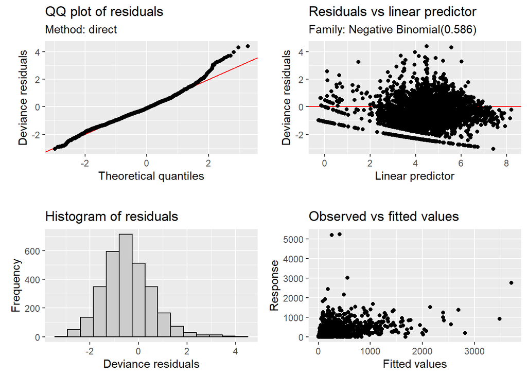

```r
#par(mfcol=c(3,2))
#plot(model2i, shade = TRUE)


#checking concurvity
#concurvity(model2i,full=TRUE)

#checking assumptions
appraise(model2i)
```

```r
#over disperison test
E1 <- resid(model2i, type = "pearson")   #ok - less than 2
N <- nrow(eastcoast)
p <- length(coef(model2i))
Overdispersion <- sum(E1^2) / (N - p)
#paste('Overdispersion: ',Overdispersion) #"Overdispersion:  1.58845886919077"
```

Checking spatial auto correlation of Abundance GAMM with Moran’s I If Moran’s I is ~0 then there is no spatial autocorrelation.

```r
res <- residuals(model2i)
#res


Coords <-cbind(eastcoast$Latitude, eastcoast$Longitude)

bw <- 6

mI <-moransI(Coords,bw,res)

moran.table <-matrix(data=NA,nrow=1,ncol=6)

col.names <-c("Moran's I", "Expected I", "Z resampling", "P-value resampling","Z randomization", "P-value randomization")

colnames(moran.table) <- col.names

moran.table[1,1] <- mI$Morans.I

moran.table[1,2] <- mI$Expected.I

moran.table[1,3] <- mI$z.resampling

moran.table[1,4] <- mI$p.value.resampling

moran.table[1,5] <- mI$z.randomization

moran.table[1,6] <- mI$p.value.randomization

print(moran.table)
```

[output not shown]

## Plotting output

Plotting effects of the larval fish abundance GAMM.

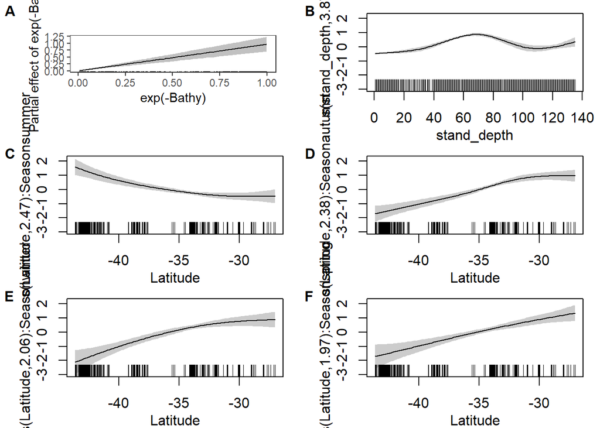

```r
# plot Bathymetry effect
z <- evaluate_parametric_term(model2i, "exp(-Bathy)")
#z


pbath <- ggplot(z, aes(x = value, y = partial)) +
  geom_line() +
  geom_ribbon(data=z,aes(ymin=upper,ymax=lower),alpha=0.3) +
  xlab("exp(-Bathy)") +
  ylab("Partial effect of exp(-Bathy)")  +
  geom_rug(sides ="b", color="black") +
  theme_bw() + theme(panel.grid.major = element_blank(), panel.grid.minor = element_blank()) + theme(plot.margin = margin(30,20,32,24))


#plot smooth effects and save as grob file
p1 <- as.grob(function() plot(model2i, shade = TRUE, select = 1))
#p1

p2 <- as.grob(function() plot(model2i, shade = TRUE, select = 2))
#p2

p3 <- as.grob(function() plot(model2i, shade = TRUE, select = 3))
#p3

p4 <- as.grob(function() plot(model2i, shade = TRUE, select = 4))
#p4

p5 <- as.grob(function() plot(model2i, shade = TRUE, select = 5))
#p5

figure_2 <- plot_grid(pbath, p1, p4, p2, p5, p3, labels = c('A', 'B', 'C', 'D', 'E', 'F'), label_size = 12, nrow = 3, ncol = 2)

figure_2
```

# 3) Richness GAMM

The following section contains code for the analysis of larval fish taxa richness using generalised additive mixed models (GAMM).

## Model selection

```r
# step 1) Full model
model1 <-  gam(richness ~  Season + Period +  exp(-Bathy)  +  s(stand_depth, bs =  "cs", k = 5) + s(dists_km, bs =  "cs", k = 5) + s(HadISST, bs =  "cs", k = 5)  + s(Latitude, bs =  "fs", xt = "cs", k = 5, by = Season, id = 1) + offset(log(Volume_m3)) + s(Project_name, bs = "re"), data = eastcoast, family = nb(theta = NULL, link = "log"), method = "REML", fit=TRUE,  Select=TRUE)


#concurvity(model1, full=T) #checking concurvity

# step 2)  s(dists_km, bs =  "cs", k = 5) + s(HadISST, bs =  "cs", k = 5)  removed due to concurvity
model2 <-  gam(richness ~  Season + Period +  exp(-Bathy)  +  s(stand_depth, bs =  "cs", k = 5)  + s(Latitude, bs =  "fs", xt = "cs", k = 5, by = Season, id = 1) + offset(log(Volume_m3)) + s(Project_name, bs = "re"), data = eastcoast, family = nb(theta = NULL, link = "log"), method = "REML", fit=TRUE,  Select=TRUE)


# Step 3) Period removed based on AIC score, checked with chi-sq test
model2i <-  gam(richness ~  Season  +  exp(-Bathy)  +  s(stand_depth, bs =  "cs", k = 5)  + s(Latitude, bs =  "fs", xt = "cs", k = 5, by = Season, id = 1) + offset(log(Volume_m3)) + s(Project_name, bs = "re"), data = eastcoast, family = nb(theta = NULL, link = "log"), method = "REML", fit=TRUE,  Select=TRUE)

#AIC(model2,model2i) ## AIC reduced with period removed

#anova(model2,model2i, test = "Chisq") #non sig therefore can remove period (adds nothing to model)



# Step 4) linear Season term removed, but increases AIC and is sig dif in chi-sq test there retain Season in model
model3 <-  gam(richness ~  exp(-Bathy)  +  s(stand_depth, bs =  "cs", k = 5)  + s(Latitude, bs =  "fs", xt = "cs", k = 5, by = Season, id = 1) + offset(log(Volume_m3)) + s(Project_name, bs = "re"), data = eastcoast, family = nb(theta = NULL, link = "log"), method = "REML", fit=TRUE,  Select=TRUE)


#AIC(model3,model2i) ## AIC increased when season removed. ## model2i best model here.

#anova(model3,model2i, test = "Chisq")  #sig dif therefore don't remove season

## therefore best model for richness appears to be model2i, removing Period based on AIC and s(dists_km, bs =  "cs", k = 5) + s(HadISST, bs =  "cs", k = 5) based on concurvity.


#Best model summary
summary(model2i)
```

```
##
## Family: Negative Binomial(2.032)
## Link function: log
##
## Formula:
## richness ~ Season + exp(-Bathy) + s(stand_depth, bs = "cs", k = 5) +
##     s(Latitude, bs = "fs", xt = "cs", k = 5, by = Season, id = 1) +
##     offset(log(Volume_m3)) + s(Project_name, bs = "re")
##
## Parametric coefficients:
##              Estimate Std. Error z value Pr(>|z|)
## (Intercept)  -3.98100    0.20233 -19.676  < 2e-16 ***
## Seasonspring -0.45834    0.07145  -6.415 1.41e-10 ***
## Seasonsummer  0.11461    0.04220   2.716  0.00661 **
## Seasonwinter -0.37823    0.06931  -5.457 4.85e-08 ***
## exp(-Bathy)   0.83862    0.07820  10.724  < 2e-16 ***
## ---
## Signif. codes:  0 '***' 0.001 '**' 0.01 '*' 0.05 '.' 0.1 ' ' 1
##
## Approximate significance of smooth terms:
##                            edf Ref.df Chi.sq  p-value
## s(stand_depth)           3.866      4  604.4  < 2e-16 ***
## s(Latitude):Seasonautumn 2.573      4  483.0  < 2e-16 ***
## s(Latitude):Seasonspring 2.169      4  749.8 7.61e-09 ***
## s(Latitude):Seasonsummer 2.714      4  178.0   0.0128 *
## s(Latitude):Seasonwinter 2.233      4  435.8 1.76e-13 ***
## s(Project_name)          9.557     10  570.9  < 2e-16 ***
## ---
## Signif. codes:  0 '***' 0.001 '**' 0.01 '*' 0.05 '.' 0.1 ' ' 1
##
## R-sq.(adj) =  -0.0346   Deviance explained = 45.4%
## -REML = 9823.8  Scale est. = 1         n = 3000
```

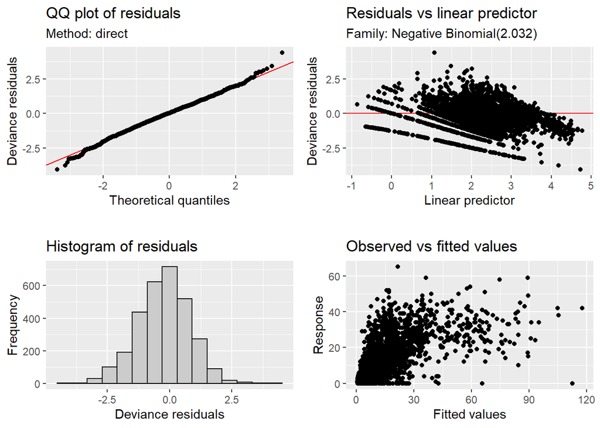

```r
#par(mfcol=c(3,2))
#plot(model2i, shade = TRUE) ### spline plots

#checking concurvity
#concurvity(model2i,full=TRUE)

#checking assumptions
appraise(model2i)
```

```r
#overdisperison test
E1 <- resid(model2i, type = "pearson")   #ok - less than 2
N <- nrow(eastcoast)
p <- length(coef(model2i))
Overdispersion <- sum(E1^2) / (N - p)
#paste('Overdispersion: ',Overdispersion) #"Overdispersion:  1.01888080182827"
```

Checking spatial auto correlation of Taxa Richness GAMM with Moran’s I If Moran’s I is ~0 then there is no spatial autocorrelation.

```r
res <- residuals(model2i)
#res


Coords <-cbind(eastcoast$Latitude, eastcoast$Longitude)

bw <- 6

mI <-moransI(Coords,bw,res)

moran.table <-matrix(data=NA,nrow=1,ncol=6)

col.names <-c("Moran's I", "Expected I", "Z resampling", "P-value resampling","Z randomization", "P-value randomization")

colnames(moran.table) <- col.names

moran.table[1,1] <- mI$Morans.I

moran.table[1,2] <- mI$Expected.I

moran.table[1,3] <- mI$z.resampling

moran.table[1,4] <- mI$p.value.resampling

moran.table[1,5] <- mI$z.randomization

moran.table[1,6] <- mI$p.value.randomization

print(moran.table)
```

[output not shown]

## Plotting output

Plotting effects of the larval fish taxa richness GAMM.

## Figure 3.

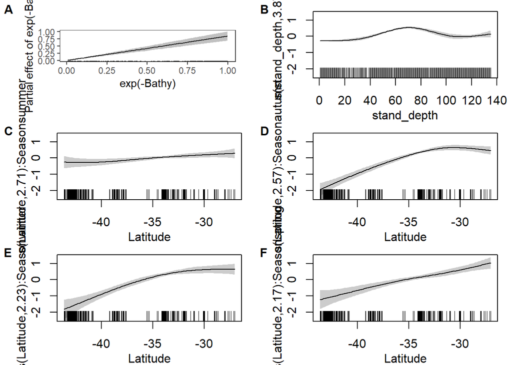

```r
z <- evaluate_parametric_term(model2i, "exp(-Bathy)")
#z


pbath <- ggplot(z, aes(x = value, y = partial)) +
  geom_line() +
  geom_ribbon(data=z,aes(ymin=upper,ymax=lower),alpha=0.3) +
  xlab("exp(-Bathy)") +
  ylab("Partial effect of exp(-Bathy)")  +
  geom_rug(sides ="b", color="black") +
  theme_bw() + theme(panel.grid.major = element_blank(), panel.grid.minor = element_blank()) + theme(plot.margin = margin(30,20,32,24))



p1 <- as.grob(function() plot(model2i, shade = TRUE, select = 1))
#p1

p2 <- as.grob(function() plot(model2i, shade = TRUE, select = 2))
#p2


p3 <- as.grob(function() plot(model2i, shade = TRUE, select = 3))
#p3

p4 <- as.grob(function() plot(model2i, shade = TRUE, select = 4))
#p4

p5 <- as.grob(function() plot(model2i, shade = TRUE, select = 5))
#p5

figure_3 <- plot_grid(pbath, p1, p4, p2, p5, p3, labels = c('A', 'B', 'C', 'D', 'E', 'F'), label_size = 12, nrow = 3, ncol = 2)

figure_3
```

# 4) Multivariate Analyses

This section of the scripts uses an intercept-only multivariate generalised linear model (MGLM) model of the larval fish community in a Gaussian copula graphical model (GCGM), and quantile regression of the , to observe the effects of temperature (Figure 4), latitude (Supplementary Figure 2) and time period (Supplementary Figure 3).

Select inshore species in matrix to analyse

```r
elements <- inshore[1:2428,22:239]



myvars <- names(elements) %in% c("Acropomatidae_Synagrops.spp_37311949",
                            "Aploactinidae_other_37290000",
                            "Bothidae_Crossorhombus.spp_37460907",
                            "Bovichtidae_Pseudaphritis.urvilli_37403003",
                            "Callanthiidae_other_37311957",
                            "Cepolidae_Acanthocepola.spp_37380901",
                            "Cepolidae_Owstonia.spp_37380903",
                            "Cepolidae_other_37380000",
                            "Cetomimidae_37132000",
                            "Chandidae_other_37310900",
                            "Engraulidae_other_37086000",
                            "Ipnopidae_37123000",
                            "Latridae_other_37378000",
                            "Leptobramidae_37357905",
                            "Microcanthidae_other_37361900",
                            "Ophidiidae_Brotula.spp_37228912",
                            "Plesiopidae_37316000",
                            "Terapontidae_other_37321000",
                            "Xiphiidae_Xiphias.gladius_37442001")


elements <- elements[!myvars] #removing species which never occur on in less than 200m bathymetry on the east coast.


elements <- mvabund(elements[,])
```

## Fitting GCGM with intercept only MGLM

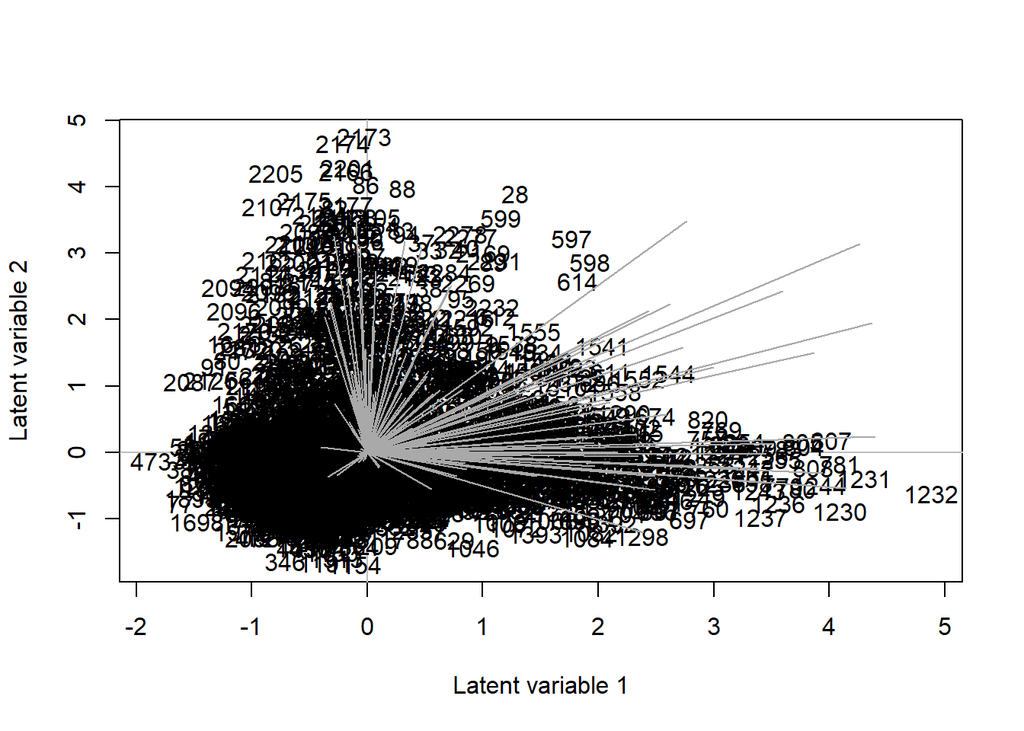

```r
#boxplot(elements) # inspect data ranges

#meanvar.plot(elements) # check mean variance relationship


#fit <- manyglm(elements ~Latitude, family = "negative.binomial", offset = log(Volume_m3),data=inshore)

fit_null <- manyglm(elements ~1, family = "negative.binomial", offset = log(Volume_m3),data=inshore)



fit_cop <- cord(fit_null)
plot(fit_cop,biplot=TRUE)
```

```r
score_1 <- fit_cop$scores[[1]][1,]
score_2 <- fit_cop$scores[[1]][2,]
```

Plot GCGM bivariate scores 1 and 2 with SST, and then latitude.

```r
plot_dat <- data.frame(score_1,score_2,inshore$Region, inshore$Latitude, inshore$HadISST, inshore$Period)

SST_bivariate_plot <- ggplot(plot_dat,aes(x=score_1,y=score_2,col=inshore.HadISST))+
  geom_point() +
  xlab("Score 1") +
  ylab("Score 2") +
  scale_color_continuous(high = "red", low = "blue") +
  theme_bw() +
  theme(legend.position=c(0.85, .9), legend.title = element_text(size=10, face="bold"),
               legend.text = element_text(size = 10, face = "bold"))



LAT_bivariate_plot <- ggplot(plot_dat,aes(x=score_1,y=score_2,col=inshore.Latitude))+
  geom_point() +
  xlab("Score 1") +
  ylab("Score 2") +
  scale_color_continuous(high = "red", low = "blue") +
  theme_bw() +
  theme(legend.position=c(0.85, .9), legend.title = element_text(size=10, face="bold"),
               legend.text = element_text(size = 10, face = "bold"))
```

## Quantile regression of bivariate scores against SST

Quantile regression of score 1 from GCGM against SST

```r
qs <- c(0.05, 0.5, 0.95) ### What quantiles are we interested in... 5%, 50% and 95%

#quantile regression for score 1
qr1 <- rq(score_1 ~ inshore.HadISST, data=plot_dat, tau = qs)

SM <- summary(qr1, se = "boot", bsmethod = "wild", R = 1000)  ## method of calculating SE and bootstrap method if applicable
SM
```

```
##
## Call: rq(formula = score_1 ~ inshore.HadISST, tau = qs, data = plot_dat)
##
## tau: [1] 0.05
##
## Coefficients:
##                 Value     Std. Error t value   Pr(>|t|)
## (Intercept)      -1.46418   0.08469  -17.28774   0.00000
## inshore.HadISST   0.02291   0.00444    5.15674   0.00000
##
## Call: rq(formula = score_1 ~ inshore.HadISST, tau = qs, data = plot_dat)
##
## tau: [1] 0.5
##
## Coefficients:
##                 Value     Std. Error t value   Pr(>|t|)
## (Intercept)      -1.50302   0.09426  -15.94554   0.00000
## inshore.HadISST   0.06436   0.00526   12.23176   0.00000
##
## Call: rq(formula = score_1 ~ inshore.HadISST, tau = qs, data = plot_dat)
##
## tau: [1] 0.95
##
## Coefficients:
##                 Value    Std. Error t value  Pr(>|t|)
## (Intercept)     -4.01042  0.54056   -7.41905  0.00000
## inshore.HadISST  0.29237  0.02895   10.09952  0.00000
```

Plotting quantile regression score 1 from GCGM against SST

```r
### Build a ggplot
p <- ggplot(plot_dat, aes(x = inshore.HadISST, y = score_1)) +
  geom_point(size = 3, na.rm = TRUE, shape = 1)

p <- p + theme_bw() + theme(panel.grid.major = element_blank(), panel.grid.minor = element_blank())

p <- p + geom_abline(intercept = qr1$coefficients[1,1], slope = qr1$coefficients[2,1],
                     linetype = 'longdash', col = "blue") # 5th quantile
p <- p + geom_abline(intercept = qr1$coefficients[1,2], slope = qr1$coefficients[2,2], col = "blue")
                   #  linetype = 'longdash' ) # 50th quantile
p <- p + geom_abline(intercept = qr1$coefficients[1,3], slope = qr1$coefficients[2,3],
                     linetype = 'longdash', col = "blue") # 95th quantile
p <- p + xlab("SST (°C)")
p <- p + ylab("Score 1")
p <- p + theme(axis.text=element_text(size=16, face = "bold"))
p <- p + theme(axis.title=element_text(size=16, face = "bold"))
p_score1 <- p + theme(legend.position=c(0.15, .8), legend.title = element_text(size=16, face="bold"),
               legend.text = element_text(size = 16, face = "bold"))
#p_score1
```

Quantile regression of score 2 from GCGM against SST

```r
qs <- c(0.05, 0.5, 0.95) ### What quantiles are we interested in... 5%, 50% and 95%

#quantile regression for score 1
qr2 <- rq(score_2 ~ inshore.HadISST, data=plot_dat, tau = qs)

SM <- summary(qr2, se = "boot", bsmethod = "wild", R = 1000)  ## method of calculating SE and bootstrap method if applicable
SM
```

```
##
## Call: rq(formula = score_2 ~ inshore.HadISST, tau = qs, data = plot_dat)
##
## tau: [1] 0.05
##
## Coefficients:
##                 Value     Std. Error t value   Pr(>|t|)
## (Intercept)      -1.84492   0.13320  -13.85082   0.00000
## inshore.HadISST   0.04684   0.00723    6.47927   0.00000
##
## Call: rq(formula = score_2 ~ inshore.HadISST, tau = qs, data = plot_dat)
##
## tau: [1] 0.5
##
## Coefficients:
##                 Value     Std. Error t value   Pr(>|t|)
## (Intercept)      -2.17395   0.12361  -17.58653   0.00000
## inshore.HadISST   0.10387   0.00657   15.80505   0.00000
##
## Call: rq(formula = score_2 ~ inshore.HadISST, tau = qs, data = plot_dat)
##
## tau: [1] 0.95
##
## Coefficients:
##                 Value     Std. Error t value   Pr(>|t|)
## (Intercept)      -4.28122   0.13235  -32.34750   0.00000
## inshore.HadISST   0.28888   0.00879   32.86453   0.00000
```

Plotting quantile regression score 2 from GCGM against SST

```r
### Build a ggplot
p <- ggplot(plot_dat, aes(x = inshore.HadISST, y = score_2)) +
  geom_point(size = 3, na.rm = TRUE, shape = 1)
p <- p + theme_bw() + theme(panel.grid.major = element_blank(), panel.grid.minor = element_blank()) ## set up plot area
p <- p + geom_abline(intercept = qr2$coefficients[1,1], slope = qr2$coefficients[2,1],
                     linetype = 'longdash', col = "blue") # 5th quantile
p <- p + geom_abline(intercept = qr2$coefficients[1,2], slope = qr2$coefficients[2,2], col = "blue")
                   #  linetype = 'longdash' ) # 50th quantile
p <- p + geom_abline(intercept = qr2$coefficients[1,3], slope = qr2$coefficients[2,3],
                     linetype = 'longdash', col = "blue") # 95th quantile
p <- p + xlab("SST (°C)")
p <- p + ylab("Score 2")
p <- p + theme(axis.text=element_text(size=16, face = "bold"))
p <- p + theme(axis.title=element_text(size=16, face = "bold"))
p_score2 <- p + theme(legend.position=c(0.15, .8), legend.title = element_text(size=16, face="bold"),
               legend.text = element_text(size = 16, face = "bold"))
#p_score2
```

Plotting the GCGM bivariate scores 1 and 2 with SST, and quantile regression plots, as per Figure 4 in the manuscript.

## Figure 4.

Figure 4. A) GCGM bivariate scores 1 and 2 from the MGLM intercept-only model of all larval fish taxa abundances . Each point represents an assemblage and the colour of the points represents SST in °C. B) GCGM bivariate score 1 by SST and C) GCGM bivariate score 2 by SST. Blue lines represent 0.05, 0.5 and 0.95 quantiles. n = 2428.

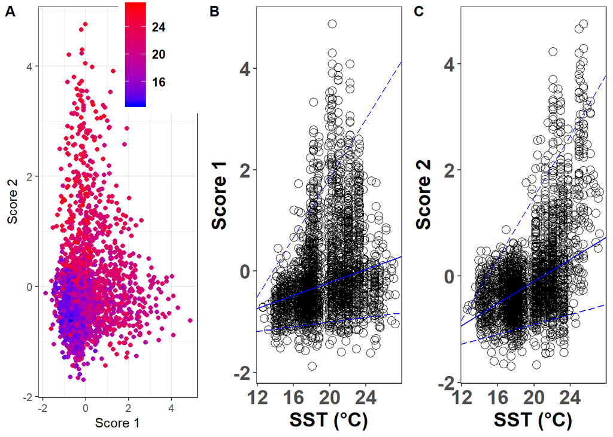

```r
figure_4 <- plot_grid(SST_bivariate_plot, p_score1, p_score2, labels = c('A', 'B', 'C'), label_size = 12, nrow = 1, ncol = 3)

figure_4
```

## Univariate tests for MGLM with SST

The univariate tests for the MGLM with SST were run on the University of New South Wales computational cluster ‘Katana’ supported by Research Technology Services. The r script included in the repo ‘manyglm_uni_test.R’ contains the analyses. Here, we import the output to observe the results.

Read in rds and display output

```r
Uni_test_manyglm_output <- readRDS("Uni_test_manyglm_output.rds")

#Uni_test_manyglm_output

#Uni_test_manyglm_output$uni.p
uni_p <- as.data.frame(Uni_test_manyglm_output$uni.p)
#uni_p


uni_ts <- as.data.frame(Uni_test_manyglm_output$uni.test)
#uni_ts

useful_output <- rbind(uni_p, uni_ts)
#useful_output

useful_output <- t(useful_output)

useful_output <- as.data.frame(useful_output)

sig_out <- subset(useful_output, useful_output$HadISST <= 0.05)

#sig_out




#sum(useful_output$HadISST1) #whole test dev

useful_output$dev_exp <- (useful_output$HadISST1/sum(useful_output$HadISST1))*100

#useful_output


useful_output <- useful_output %>%
  rename(
    P = HadISST,
    TS = HadISST1
    ) %>%
  select(P, TS, dev_exp)



head(useful_output)
```

```
##                                                P         TS      dev_exp
## Acanthuridae_37437000                     0.0001 156.978730 1.1467679622
## Acropomatidae_Apogonops.anomalus_37311053 0.0001  95.979510 0.7011537639
## Acropomatidae_other_37311956              1.0000   0.111148 0.0008119635
## Ammodytidae_37425000                      0.0002  56.514417 0.4128516210
## Anguilliformes_37990019                   0.0001 271.926545 1.9864898281
## Antennariidae_37210000                    0.4399   9.786945 0.0714960249
```

```r
#write.csv(useful_output, "manyglm_temp_uni.csv")
```

## Quantile regression of bivariate scores against Latitude

Now running quantile regression of score 1 from GCGM against Latitude

```r
qs <- c(0.05, 0.5, 0.95) ### What quantiles are we interested in... 5%, 50% and 95%

#quantile regression for score 1
qr1 <- rq(score_1 ~ inshore.Latitude, data=plot_dat, tau = qs)

SM <- summary(qr1, se = "boot", bsmethod = "wild", R = 1000)  ## method of calculating SE and bootstrap method if applicable
SM
```

```
##
## Call: rq(formula = score_1 ~ inshore.Latitude, tau = qs, data = plot_dat)
##
## tau: [1] 0.05
##
## Coefficients:
##                  Value    Std. Error t value  Pr(>|t|)
## (Intercept)      -0.46350  0.17335   -2.67375  0.00755
## inshore.Latitude  0.01580  0.00469    3.36992  0.00076
##
## Call: rq(formula = score_1 ~ inshore.Latitude, tau = qs, data = plot_dat)
##
## tau: [1] 0.5
##
## Coefficients:
##                  Value    Std. Error t value  Pr(>|t|)
## (Intercept)       1.42931  0.11535   12.39081  0.00000
## inshore.Latitude  0.04724  0.00306   15.45606  0.00000
##
## Call: rq(formula = score_1 ~ inshore.Latitude, tau = qs, data = plot_dat)
##
## tau: [1] 0.95
##
## Coefficients:
##                  Value    Std. Error t value  Pr(>|t|)
## (Intercept)       9.58603  0.40831   23.47716  0.00000
## inshore.Latitude  0.22208  0.01057   21.01388  0.00000
```

Plotting quantile regression score 1 from GCGM against Latitude

```r
### Build a ggplot
p <- ggplot(plot_dat, aes(x = inshore.Latitude, y = score_1)) +
  geom_point(size = 3, na.rm = TRUE, shape = 1)

p <- p + theme_bw() + theme(panel.grid.major = element_blank(), panel.grid.minor = element_blank())

p <- p + geom_abline(intercept = qr1$coefficients[1,1], slope = qr1$coefficients[2,1],
                     linetype = 'longdash', col = "blue") # 5th quantile
p <- p + geom_abline(intercept = qr1$coefficients[1,2], slope = qr1$coefficients[2,2], col = "blue")
                   #  linetype = 'longdash' ) # 50th quantile
p <- p + geom_abline(intercept = qr1$coefficients[1,3], slope = qr1$coefficients[2,3],
                     linetype = 'longdash', col = "blue") # 95th quantile
p <- p + xlab("Latitude (°)")
p <- p + ylab("Score 1")
p <- p + theme(axis.text=element_text(size=16, face = "bold"))
p <- p + theme(axis.title=element_text(size=16, face = "bold"))
p_score1 <- p + theme(legend.position=c(0.15, .8), legend.title = element_text(size=16, face="bold"),
               legend.text = element_text(size = 16, face = "bold"))
#p_score1
```

```r
qs <- c(0.05, 0.5, 0.95) ### What quantiles are we interested in... 5%, 50% and 95%

#quantile regression for score 1
qr2 <- rq(score_2 ~ inshore.Latitude, data=plot_dat, tau = qs)

SM <- summary(qr2, se = "boot", bsmethod = "wild", R = 1000)  ## method of calculating SE and bootstrap method if applicable
SM
```

```
##
## Call: rq(formula = score_2 ~ inshore.Latitude, tau = qs, data = plot_dat)
##
## tau: [1] 0.05
##
## Coefficients:
##                  Value    Std. Error t value  Pr(>|t|)
## (Intercept)      -0.08068  0.21772   -0.37058  0.71098
## inshore.Latitude  0.02462  0.00601    4.09674  0.00004
##
## Call: rq(formula = score_2 ~ inshore.Latitude, tau = qs, data = plot_dat)
##
## tau: [1] 0.5
##
## Coefficients:
##                  Value    Std. Error t value  Pr(>|t|)
## (Intercept)       1.58956  0.16467    9.65318  0.00000
## inshore.Latitude  0.04990  0.00438   11.38512  0.00000
##
## Call: rq(formula = score_2 ~ inshore.Latitude, tau = qs, data = plot_dat)
##
## tau: [1] 0.95
##
## Coefficients:
##                  Value    Std. Error t value  Pr(>|t|)
## (Intercept)       8.61369  0.25261   34.09846  0.00000
## inshore.Latitude  0.19815  0.00614   32.24841  0.00000
```

Plotting quantile regression score 2 from GCGM against Latitude

```r
### Buiild a ggplot
p <- ggplot(plot_dat, aes(x = inshore.Latitude, y = score_2)) +
  geom_point(size = 3, na.rm = TRUE, shape = 1)
p <- p + theme_bw() + theme(panel.grid.major = element_blank(), panel.grid.minor = element_blank()) ## set up plot area
p <- p + geom_abline(intercept = qr2$coefficients[1,1], slope = qr2$coefficients[2,1],
                     linetype = 'longdash', col = "blue") # 5th quantile
p <- p + geom_abline(intercept = qr2$coefficients[1,2], slope = qr2$coefficients[2,2], col = "blue")
                   #  linetype = 'longdash' ) # 50th quantile
p <- p + geom_abline(intercept = qr2$coefficients[1,3], slope = qr2$coefficients[2,3],
                     linetype = 'longdash', col = "blue") # 95th quantile
p <- p + xlab("Latitude (°)")
p <- p + ylab("Score 2")
p <- p + theme(axis.text=element_text(size=16, face = "bold"))
p <- p + theme(axis.title=element_text(size=16, face = "bold"))
p_score2 <- p + theme(legend.position=c(0.15, .8), legend.title = element_text(size=16, face="bold"),
               legend.text = element_text(size = 16, face = "bold"))
#p_score2
```

Plotting the GCGM bivariate scores 1 and 2 with Latitude, and quantile regression plots, as per Supplementary Figure 2 in the manuscript.

## Supp Figure 2.

Supplementary Figure 2. A) GCGM bivariate scores 1 and 2. Each point represents an assemblage and the colour of the points represents latitude. B) GCGM bivariate score 1 by latitude and C) GCGM bivariate score 2 by latitude. Blue lines represent 0.05, 0.5 and 0.95 quantiles. n = 2428.

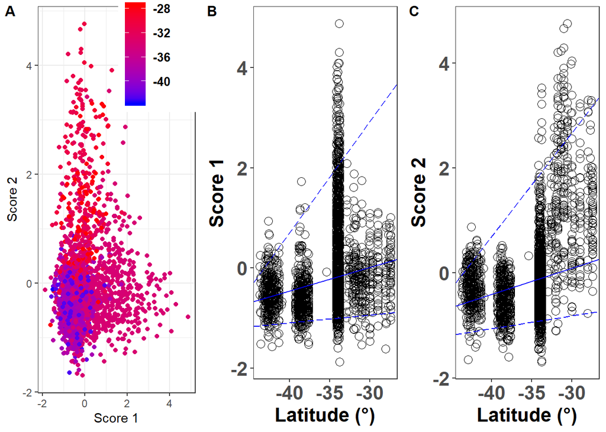

```r
supp_figure_2 <- plot_grid(LAT_bivariate_plot, p_score1, p_score2, labels = c('A', 'B', 'C'), label_size = 12, nrow = 1, ncol = 3)

supp_figure_2
```

Observing difference in community composition of larval fish taxa with latitude before and after 1998 (coinciding with the 1998/99 El Nino event)in the bivariate scores of the GCGM with intercept only MGLM.

## Supp Figure 3.

Supplementary Figure 3. A) GCGM bivariate scores 1 and 2. Each point represents an assemblage and the colour of the points represents the ‘Period’, black circles are pre-1998 and orange circles are post-1998. B) GCGM bivariate score 1 by latitude and C) GCGM bivariate score 2 by latitude. Trend lines are fit with a loess smoother.

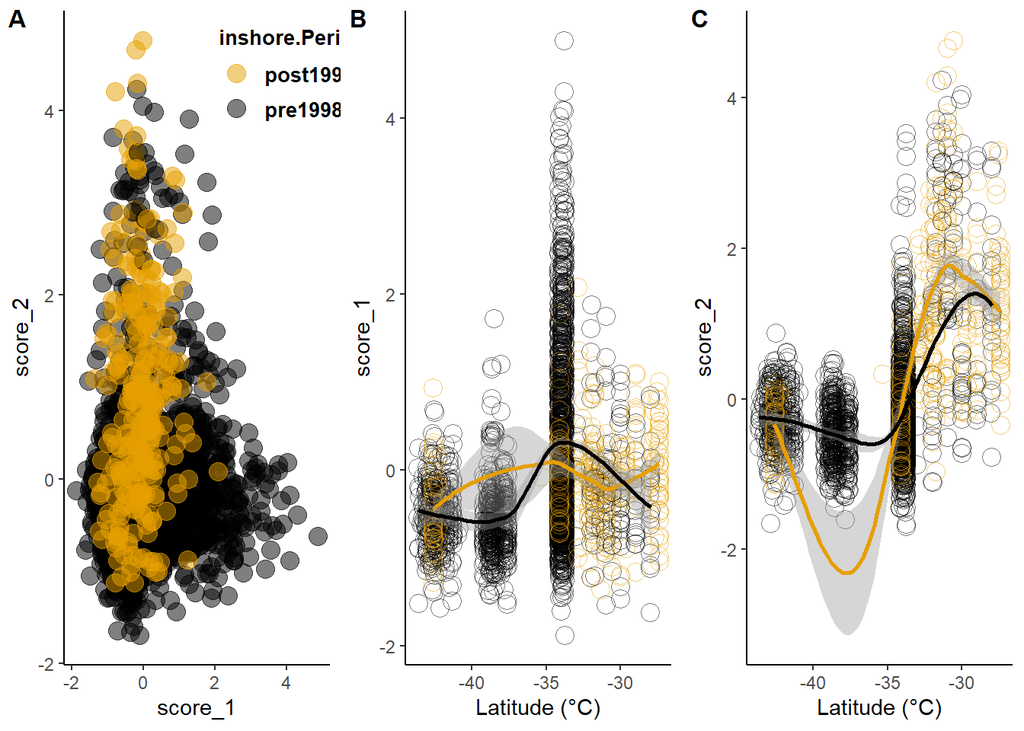

```r
my_cols <- c("#E69F00", "#000000")

p1<- ggplot(plot_dat,aes(x=score_1,y=score_2))+
  geom_point(aes(color = inshore.Period), size = 4, alpha = 0.5) +
  scale_color_manual(values = my_cols) +
  theme_classic() +
  theme(legend.position=c(0.85, .9), legend.title = element_text(size=10, face="bold"),
               legend.text = element_text(size = 10, face = "bold"))

#p1

p2 <- ggplot(plot_dat,aes(x=inshore.Latitude, y=score_1, col=inshore.Period))+
   geom_point(aes(color = inshore.Period), size = 4, alpha = 0.5,  shape = 1) +
  scale_color_manual(values = my_cols) +
  theme_classic() +
  xlab("Latitude (°C)") +
  theme(legend.position="none") +
  geom_smooth(method = "loess")


p3 <-  ggplot(plot_dat,aes(x=inshore.Latitude, y=score_2, col=inshore.Period))+
  geom_point(aes(color = inshore.Period), size = 4, alpha = 0.5,  shape = 1) +
  scale_color_manual(values = my_cols) +
  theme_classic() +
  xlab("Latitude (°C)") +
  theme(legend.position="none") +
  geom_smooth(method = "loess")



supp_figure_3 <- plot_grid(p1, p2, p3, labels = c('A', 'B', 'C'), label_size = 12, nrow = 1, ncol = 3)

supp_figure_3
```